# Assginment03

#### Q3 outliers

```r
num_outliers<- function(input_sample){
  quantile25<- quantile(input_sample,0.25, na.rm = TRUE)
  quantile75<- quantile(input_sample,0.75, na.rm = TRUE)
  iq_range<- quantile75 - quantile25
  outliers <- input_sample[(input_sample>quantile75+1.5*iq_range) | (input_sample<quantile25-1.5*iq_range)]
  n<-length(which(!is.na(outliers)))
  return(n)
}

num_outliers(c(0,40,60,185))
```

```
## [1] 1
```

#### Q4 Outliers by group

```r
Hawks%>%
  group_by(Species)%>%
  summarise(num_outliers_weight=num_outliers(Weight))
```

```
## # A tibble: 3 × 2
##   Species num_outliers_weight
##   <fct>                 <int>
## 1 CH                        3
## 2 RT                       13
## 3 SS                        4
```

### 1.6 Covariance and correlation

#### Q1

```r
cov(Hawks$Weight,Hawks$Wing,use = 'complete.obs')
```

```
## [1] 41174.39
```

```r
cor(Hawks$Weight,Hawks$Wing,use = 'complete.obs')
```

```
## [1] 0.9348575
```

#### Q2

```r
S_new_n<- function(X,Y,a,b,c,d){
  S <- cov(X,Y,use ='complete.obs' )
  x_new<- a*X+b
  y_new<- c*Y+d
  S_new <- abs(cov(x_new,y_new,use ='complete.obs'))

  return(S_new)
}
```

```r
S_new_n(Hawks$Weight,Hawks$Wing,2.4,7.1,-1,3)
```

```
## [1] 98818.54
```

S_new is 2.4 times than S

## 2. Random experiments, events and sample spaces, and the set theory

### 2.1 Random experiments, events and sample sapces

#### Q1 Firstly, write down the definition of a random experiment, event and sample space.

A random experiment is a procedure (real or imagined) which: 1. has a well-defined set of possible outcomes; 2. could (at least in principle) be repeated arbitrarily many times.

An event is a set (i.e. a collection) of possible outcomes of an experiment

A sample space is the set of all possible outcomes of interest for a random experiment

#### Q2 Consider a random experiment of rolling a dice twice. Give an example of what is an event in this random experiment. Also, can you write down the sample space as a set? What is the total number of different events in this experiment? Is the empty set considered as an event?

Example event : get {6,6} Total number of different events : 36 you cannot get an empty set because you must get a number when you rolling a dice

### 2.2 Set theory

#### Q1 Set operations:

Let the sets A, B, C be defined by A := {1, 2, 3}, B := {2, 4, 6}, C := {4, 5, 6}.

1. What are the unions A∪B and A∪C?
2. What are the intersections A ∩ B and A∩C?
3. What are the complements Aand A?
4. Are A and B disjoint? Are A and C disjoint?
5. Are B and Adisjoint?
6. Write down a partition of {1,2,3,4,5,6} consisting of two sets. Also, write down another partition of {1,2,3,4,5,6} consisting of three sets

Answer:  
1. unions A∪B : {1,2,3,4,6} A∪C :{1,2,3,4,5,6}  
2. intersections A ∩ B : {2} A∩C empty set  
3. complements A: {1,3} A: {1,2,3}  
4. no / yes  
5. yes  
6. {1,2,3} {4,5,6}  
{1,2} {3,4} {5,6}

#### Q2 Complements, subsets and De Morgan’s laws

Let Ω be a sample space. Recall that for an event A ⊆ Ω the complement Ac := Ω:= {w ∈ Ω : w /∈ A}. Take a pair of events A ⊆ Ω and B ⊆ Ω.  
1. Can you give an expression for (Ac)c without using the notion of a complement?  
2. What is Ωc?  
3. (Subsets) Show that if A ⊆ B, then Bc ⊆ Ac.  
4. (De Morgan’s laws) Show that (A ∩ B)c = Ac ∪ Bc. Let’s suppose we have a sequence of events A1,A2,··· ,AK ⊂ Ω. Can you write out an expression for (∩K k=1Ak)c?  
5. (De Morgan’s laws) Show that (A∪B)c = Ac ∩Bc.  
6. Let’s suppose we have a sequence of events A1,A2,··· ,AK ⊂ Ω. Can you write out an expression for (∪K k=1Ak)c?

Answer:
1. A
2. empty set
3. A: {1,2,3} B{1,2,3,4,5} Ω:{1,2,3,4,5,6,7,8,9} Ac :{4,5,6,7,8,9} Bc:{6,7,8,9}
Bc ⊆ Ac
4.
$$(∩_{k=1}^{K} A_k)^c := ∪_{k=1}^{K}
(A_k)^c$$
5.
$$A∪B: = \{1,2,3,4,5\}$$
$$(A∪B)^c: = \{6,7,8,9\}$$
$$A^c: = \{4,5,6,7,8,9\}\
B^c : =\{6,7,8,9\} \
A^c ∩ B^c := \{6,7,8,9\}\$$
6.
$$(∪_{k=1}^{K} A_k)^c :=
∩_{k=1}^{K} (A_k)^c$$

#### Q3 Cardinality and the set of all subsets:

$$E := \{A∈Ω :A∈A_i\text{ for all i =
1,2,...,K }\}$$

#### Q4 Disjointness and partitions

1. $$A_1: = \{1\}, A_2 = :\{2\},A_3 =
   :\{3\},A_4 = :\{4\},
   Ω: =\{1,2,3,4\}$$
2. $$S_1:=\{1\},S_2:=\{2\},S_3:=\{3\},S_4:=\{4\}$$
   $$S_1,S_2,S_3,S_4\text{ form a partition of}
   \{1,2,3,4\}$$

#### Q5 Indicator function

1. $$1_A{^c}(w)=\begin{array}{cc}
   \{ &
   \begin{array}{cc}
   1_A &\text{if} &w!\in A \\
   1_A & \text{if}&w ∈A
   \end{array}
   \end{array}$$
2. $$B = Ω$$

#### Q6 Uncountable infinities

## 3.Visualisation

#### Q1 Density plot:

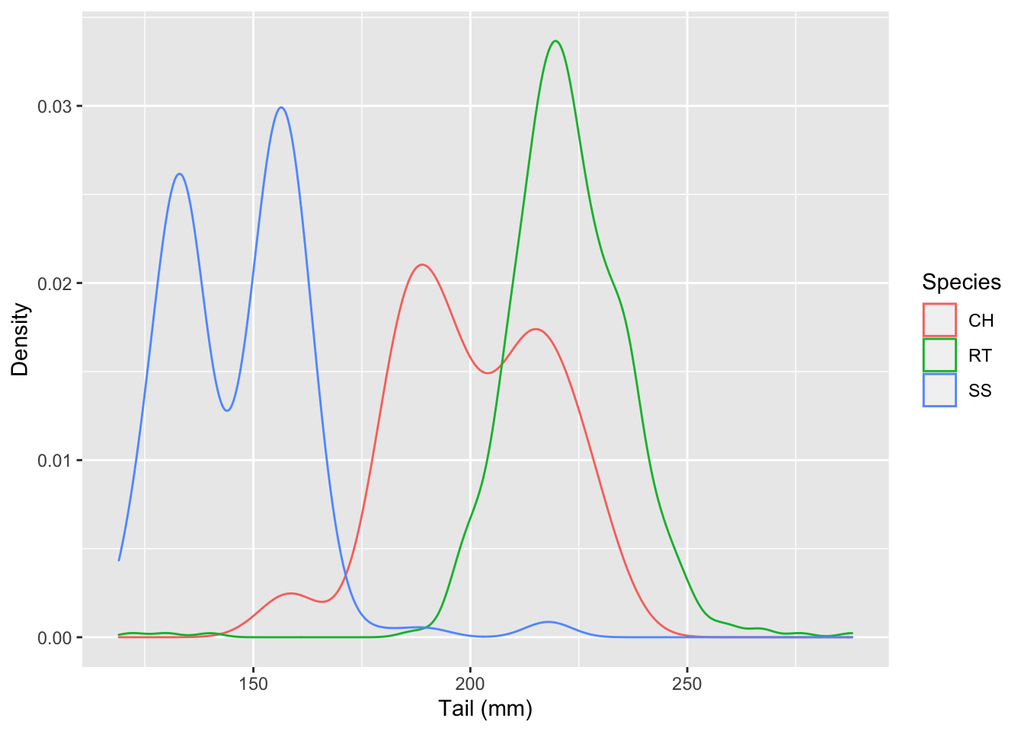

```r
library(ggplot2)
ggplot(Hawks,aes(x=Tail,group=Species,color=Species)) + geom_density()+xlab("Tail (mm)") + ylab("Density")
```

#### Q2 Violin plot:

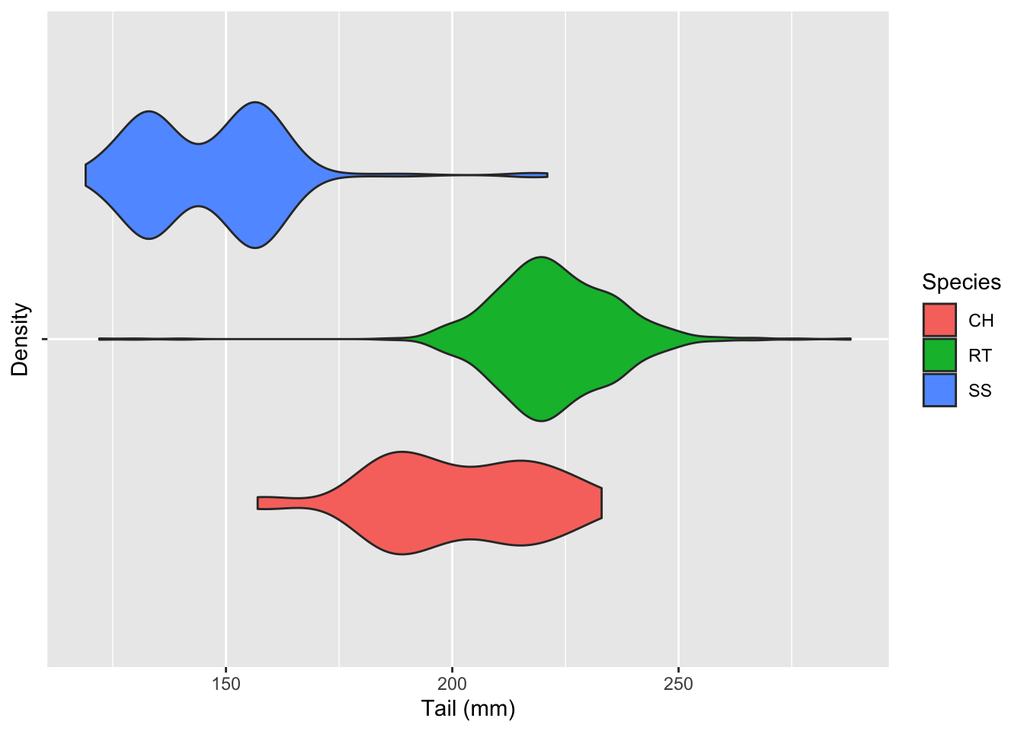

```r
ggplot(Hawks,aes(x=Tail,y="",fill=Species)) +
  geom_violin()+xlab("Tail (mm)") + ylab("Density")
```

#### Q3 Scatter plot:

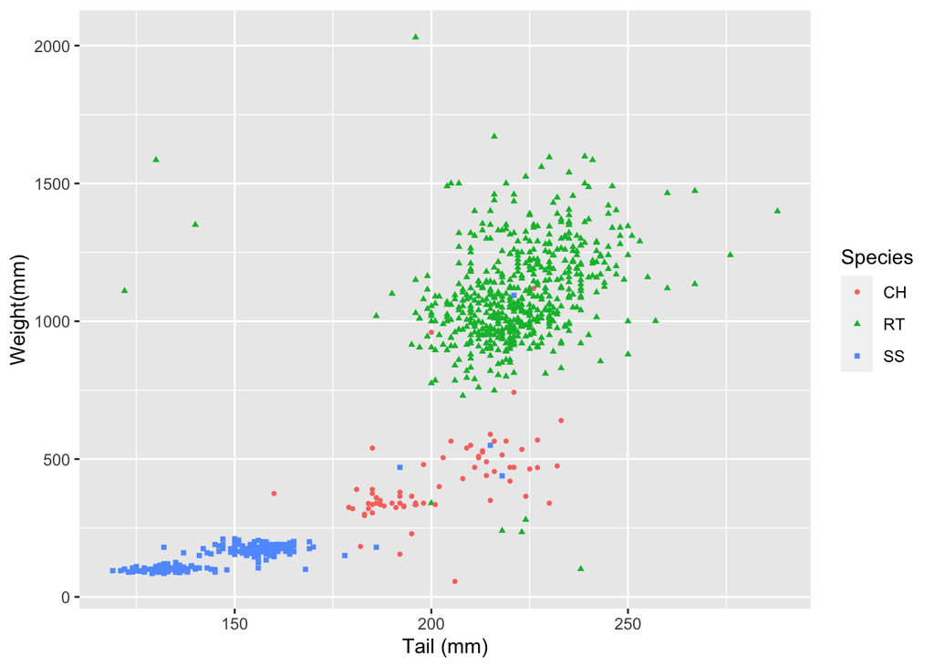

```r
ggplot(Hawks,aes(x=Tail,y=Weight,group=Species,color=Species,shape=Species)) + geom_point(size =1,na.rm = TRUE)+xlab("Tail (mm)") + ylab("Weight(mm)")
```

1. 5 types 2. key_points 3. Species

#### Q4

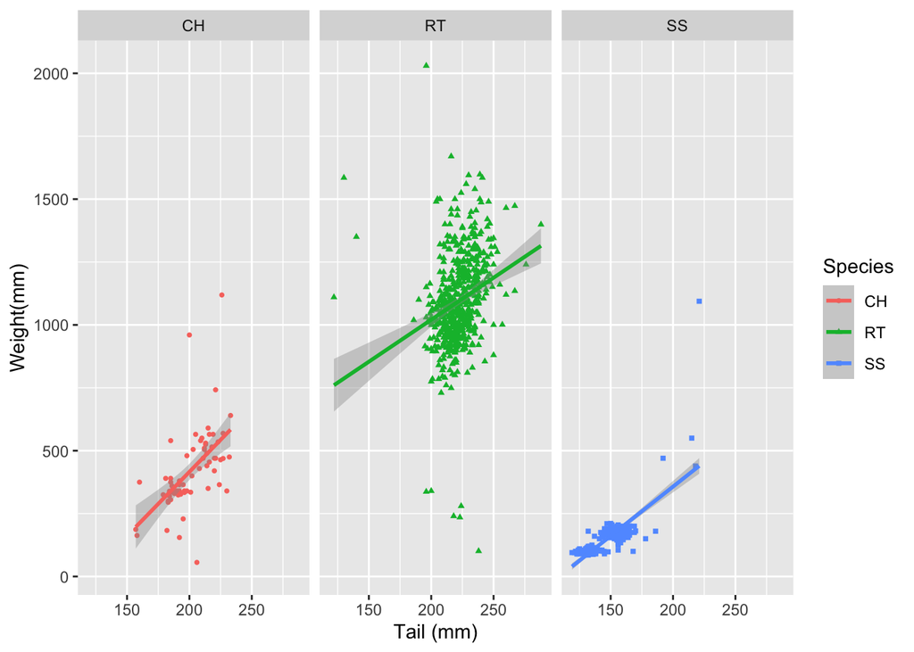

```r
ggplot(Hawks,aes(x=Tail,y=Weight,group=Species,color=Species,shape=Species)) + geom_point(size =1,na.rm = TRUE)+geom_smooth(method = "lm",na.rm = TRUE)+xlab("Tail (mm)") + ylab("Weight(mm)")+
  facet_wrap(~ Species)
```

1. Species
2. positive correlation

#### Q5

```r
library(tidyverse)
Hawks%>%
  select(Weight,Tail)%>%
  filter(Weight==max(Weight,na.rm = TRUE))
```

```
##   Weight Tail
## 1   2030  196
```

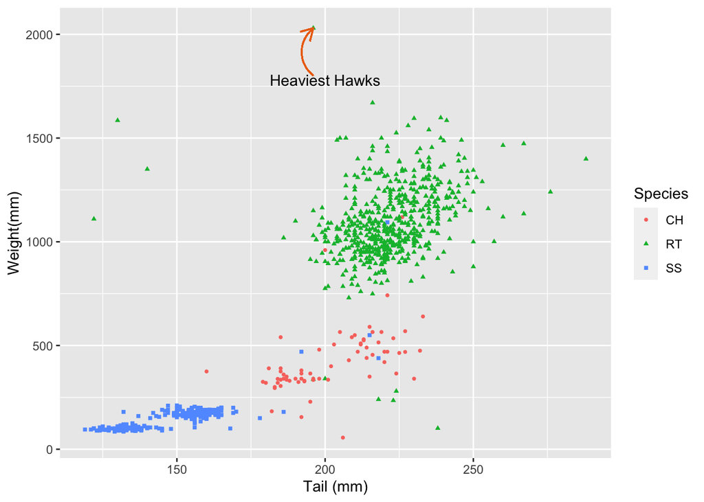

```r
ggplot(Hawks,aes(x=Tail,y=Weight,group=Species,color=Species,shape=Species)) + geom_point(size =1,na.rm = TRUE)+xlab("Tail (mm)") + ylab("Weight(mm)")+ geom_curve(
  aes(x = 196, y = 2030, xend =196, yend = 1800),
  arrow=arrow(ends ="first",length = unit(0.03,"npc"),type = "open"),
  colour = "#EC7014",
  size = 0.5,
  angle = 90 # Anything other than 90 or 0 can look unusual
)+annotate("text", x = 200, y = 1780, label = "Heaviest Hawks")
```